# DSO545: DV_Assignment_3

Alok Abhishek

February 11, 2017

## Case 1: Where Do People Drink the Most Beer, Wine, and Spirits?

## Q1:

Which countries consume at least 300 (>=300) beer drinks per person?

```r
library(dplyr)
```

```r
library(ggplot2)

#check where is our working director
getwd()
```

```
## [1] "C:/Users/alok_/OneDrive/MBA Academics/Second Semester/DSO-545 Statistical Computing and Data Visualization/Assignment/Assignment_3"
```

```r
# set the working directory
setwd("C:/Users/alok_/OneDrive/MBA Academics/Second Semester/DSO-545 Statistical Computing and Data Visualization/Assignment/Assignment_3/")

# Read the file...
drinks_data = read.csv("drinks.csv")

## Which countries consume at least 300 (>=300) beer drinks per person?

drink_300_ormore = drinks_data %>%
  filter(beer_servings>=300)

cat("Countries which consume more than 300 beers per capita are: ")
```

```
## Countries which consume more than 300 beers per capita are:
```

```r
drink_300_ormore
```

```
##          country beer_servings spirit_servings wine_servings
## 1 Czech Republic           361             170           134
## 2          Gabon           347              98            59
## 3        Germany           346             117           175
## 4        Ireland           313             118           165
## 5      Lithuania           343             244            56
## 6        Namibia           376               3             1
## 7          Palau           306              63            23
## 8         Poland           343             215            56
## 9      Venezuela           333             100             3
##   total_litres_of_pure_alcohol
## 1                         11.8
## 2                          8.9
## 3                         11.3
## 4                         11.4
## 5                         12.9
## 6                          6.8
## 7                          6.9
## 8                         10.9
## 9                          7.7
```

## Question 2:

How many countries consume at least 300 total drinks per person?

```r
## How many countries consume at least 300 total drinks per person?

no_countries_drink_300_ormore = nrow(drink_300_ormore)

cat(no_countries_drink_300_ormore, " countries consume 300 or more servings of beer per capita")
```

```
## 9  countries consume 300 or more servings of beer per capita
```

## Q3:

Amongst countries in which at least 300 total drinks were consumed per person, which country drank the most beer as a percentage of total drinks consumed, and what is that percentage?

```r
## Amongst countries in which at least 300 total drinks were consumed per person, which country drank the most beer
## as a percentage of total drinks consumed, and what is that percentage?

drink_300_ormore = drink_300_ormore %>%
  mutate(beer_percent = ((beer_servings /(beer_servings+spirit_servings+wine_servings+total_litres_of_pure_alcohol))*100))


drink_300_ormore = drink_300_ormore %>%
  arrange(desc(beer_percent))

top_beer_cons_country = top_n(drink_300_ormore,1,beer_percent)

print(top_beer_cons_country[1,1],max.levels=0)
```

```
## [1] Namibia
```

```r
cat(" consumed the most beer by percentage of total beer consumption per capita.")
```

```
##  consumed the most beer by percentage of total beer consumption per capita.
```

## Question 4:

Subset your data to include only the top 20 countries in total servings of alcohol consumed per year and create and EXACT copy of the following graph.

## I have create two plots one excatly same as the one in the assignment and another with shows total serving of alcohol including the total serving on pure alcohol…

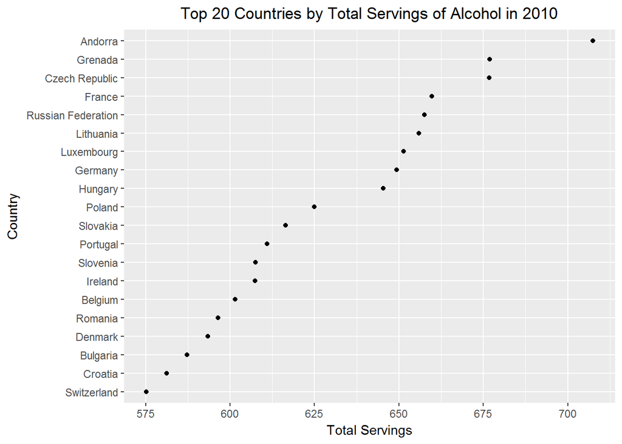

```r
## Subset your data to include only the top 20 countries in total servings of alcohol consumed per year
## and create and EXACT copy of the following graph.

drinks_data_top_20 = drinks_data %>%
  mutate(total_serving = (beer_servings+spirit_servings+wine_servings+total_litres_of_pure_alcohol)) %>%
  arrange(desc(total_serving)) %>%
  top_n(20, total_serving)

drinks_data_top_20 %>%
  ggplot(aes(x=total_serving,y=reorder(country,total_serving))) +
  geom_point() +
  scale_x_continuous(breaks = c(575,600,625,650,675,700))+
  ylab("Country")+
  xlab("Total Servings")+
  ggtitle("Top 20 Countries by Total Servings of Alcohol in 2010") + theme(plot.title = element_text(hjust = 0.5))
```

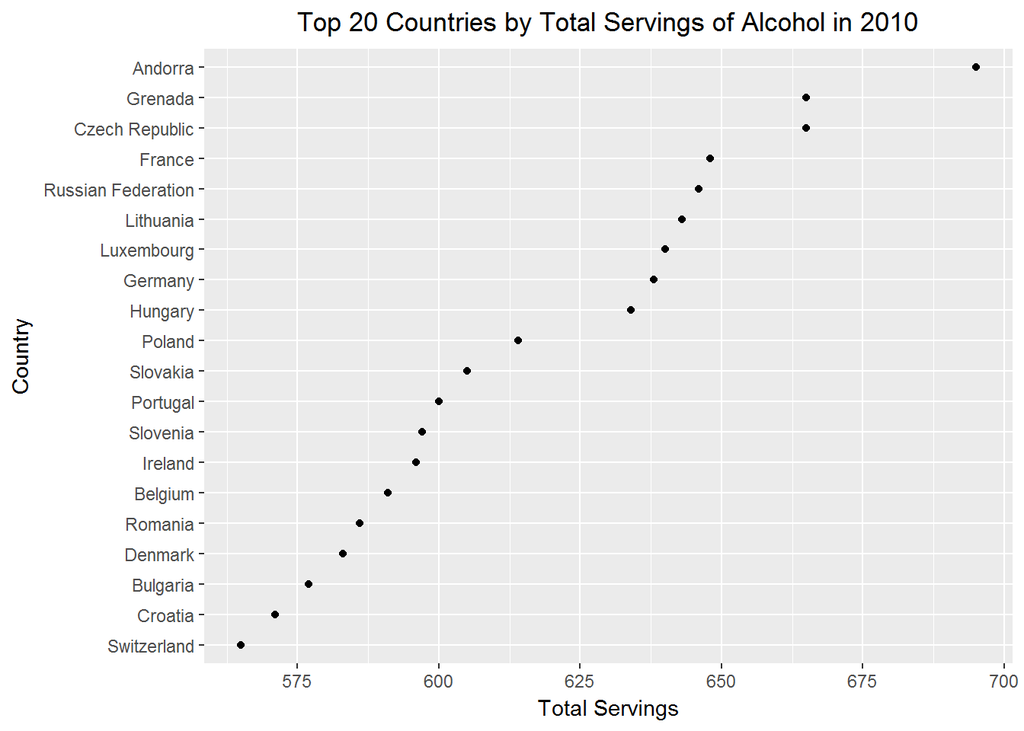

```r
## Without the pure alcohol...

drinks_data_top_20_2 = drinks_data %>%
  mutate(total_serving = (beer_servings+spirit_servings+wine_servings)) %>%
  arrange(desc(total_serving)) %>%
  top_n(20, total_serving)

drinks_data_top_20_2 %>%
  ggplot(aes(x=total_serving,y=reorder(country,total_serving))) +
  geom_point() +
  scale_x_continuous(breaks = c(575,600,625,650,675,700))+
  ylab("Country")+
  xlab("Total Servings")+
  ggtitle("Top 20 Countries by Total Servings of Alcohol in 2010") + theme(plot.title = element_text(hjust = 0.5))
```

## Case 2: Both Republicans and Democrats Have an Age Problem

## Question 5:

Create a dataframe that includes only democrats and republicans.

```r
## Case - 2

# Read the file...
congress_data = read.csv("congress.csv")

## Create a dataframe that includes only democrats and republicans.

congress_data_RD = congress_data %>%
  filter(party=="D" | party=="R")
```

## Question 6:

Create an EXACT copy of the following graph that shows the age distributin for democrats and republicans in the congress.

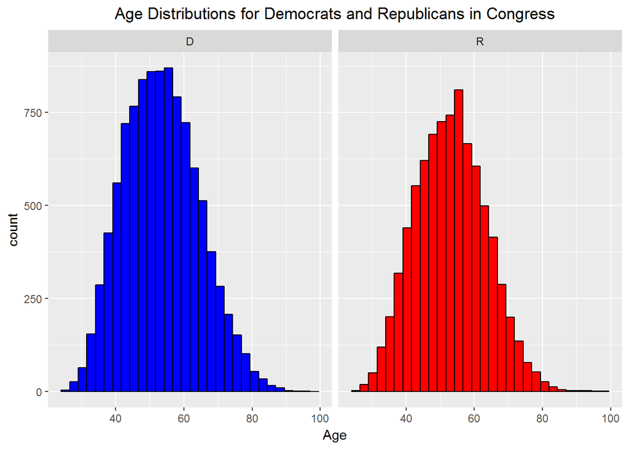

```r
## Create an EXACT copy of the following graph that shows the age distributin for democrats and
## republicans in the congress.

congress_data_RD%>%
  ggplot(aes(x=age, fill=party))+
  geom_histogram(color='black')+
  facet_grid(.~party)+
  scale_fill_manual(values=c("blue","red"),guide = FALSE) +
  xlab("Age")+
  ylab("count")+
  ggtitle("Age Distributions for Democrats and Republicans in Congress")+
  theme(plot.title = element_text(hjust = 0.5))
```

## Question 7:

Create an EXACT copy of the following graph that shows the distribution of ages for the senate and the congress (democrats and republicans combined). (Note: its okay if your graph is wider or narrower, taller or shorter)

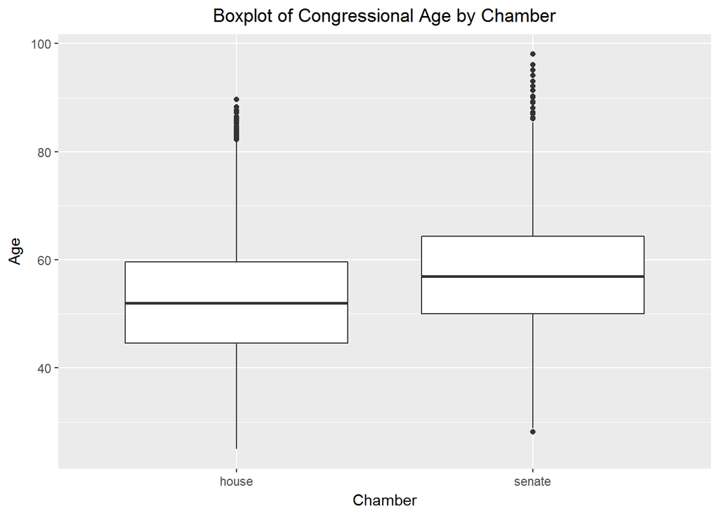

```r
## Create an EXACT copy of the following graph that shows the distribution of ages for the senate and
## the congress (democrats and republicans combined). (Note: its okay if your graph is wider or narrower, taller or shorter)

ggplot(congress_data_RD,aes(x=chamber,y=age))+
  geom_boxplot(outlier.shape = 19)+
  xlab("Chamber") +
  ylab("Age") +
  ggtitle("Boxplot of Congressional Age by Chamber")+
  theme(plot.title = element_text(hjust = 0.5))
```

## Question 8:

Create an EXACT copy of the following graph that shows the number of senate members for both democrats and republicans for congress 104 through congress 113.

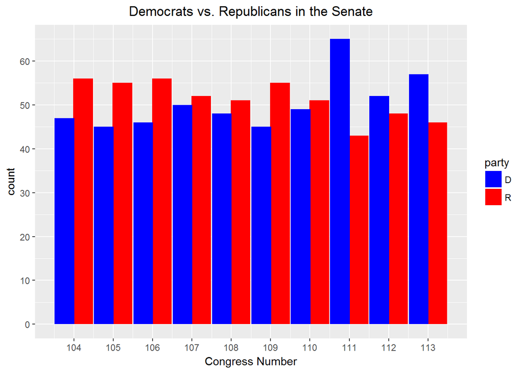

```r
## Create an EXACT copy of the following graph that shows the number of senate members for both
## democrats and republicans for congress 104 through congress 113.

congress_data_RD_2= congress_data %>%
    filter(chamber=="senate" & congress>=104 & congress<=113) %>%
  filter(party=="D" | party=="R")


ggplot(congress_data_RD_2,aes(x=congress,fill=party,group=party))+
  geom_histogram(position = position_dodge(width = 0.95), binwidth = 1)+
  scale_fill_manual(values=c("blue","red")) +
  scale_x_continuous(breaks = c(104,105,106,107,108,109,110,111,112,113))+
  scale_y_continuous(breaks = c(0,10,20,30,40,50,60))+
  xlab("Congress Number") +
  ylab("count") +
  ggtitle("Democrats vs. Republicans in the Senate")+
  theme(plot.title = element_text(hjust = 0.5))
```